# Cross_Sanchez_Sara

Sanchez_Sara

10/21/2021

#Data Frame - Variables and observations

```
## 'data.frame':    381109 obs. of  12 variables:
##  $ id                  : int  1 2 3 4 5 6 7 8 9 10 ...
##  $ Gender              : chr  "Male" "Male" "Male" "Male" ...
##  $ Age                 : int  44 76 47 21 29 24 23 56 24 32 ...
##  $ Driving_License     : int  1 1 1 1 1 1 1 1 1 1 ...
##  $ Region_Code         : num  28 3 28 11 41 33 11 28 3 6 ...
##  $ Previously_Insured  : int  0 0 0 1 1 0 0 0 1 1 ...
##  $ Vehicle_Age         : chr  "> 2 Years" "1-2 Year" "> 2 Years" "< 1 Year" ...
##  $ Vehicle_Damage      : chr  "Yes" "No" "Yes" "No" ...
##  $ Annual_Premium      : num  40454 33536 38294 28619 27496 ...
##  $ Policy_Sales_Channel: num  26 26 26 152 152 160 152 26 152 152 ...
##  $ Vintage             : int  217 183 27 203 39 176 249 72 28 80 ...
##  $ Response            : int  1 0 1 0 0 0 0 1 0 0 ...
```

#Make sure that some variables are stored as factor

#remove outliers

```
## Outliers identified: 0
## Propotion (%) of outliers: 0
## Mean of the outliers: NaN
## Mean without removing outliers: 38.82
## Mean if we remove outliers: 38.82
## Nothing changed
```

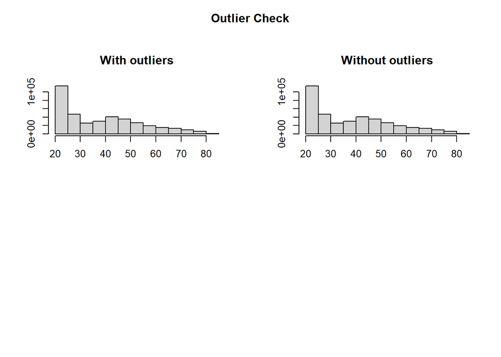

#UNIVARIATE ANALYSIS

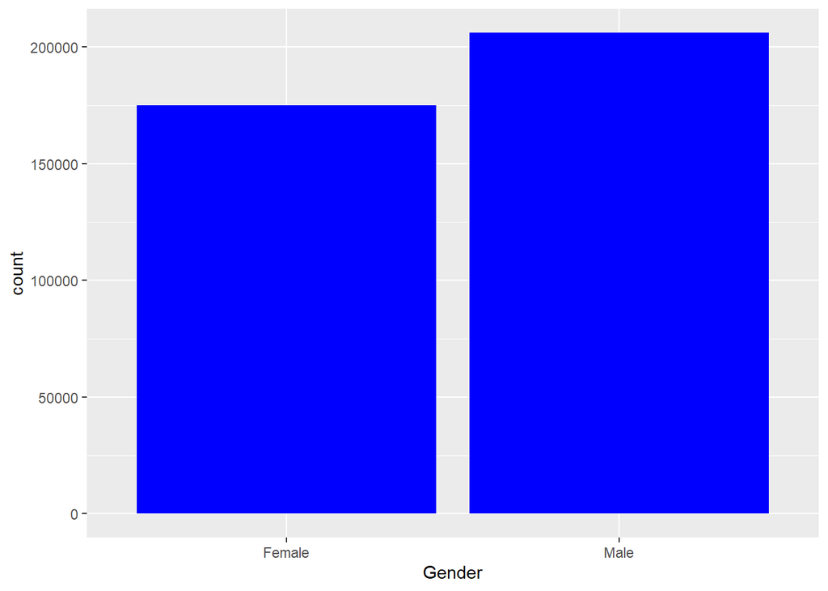

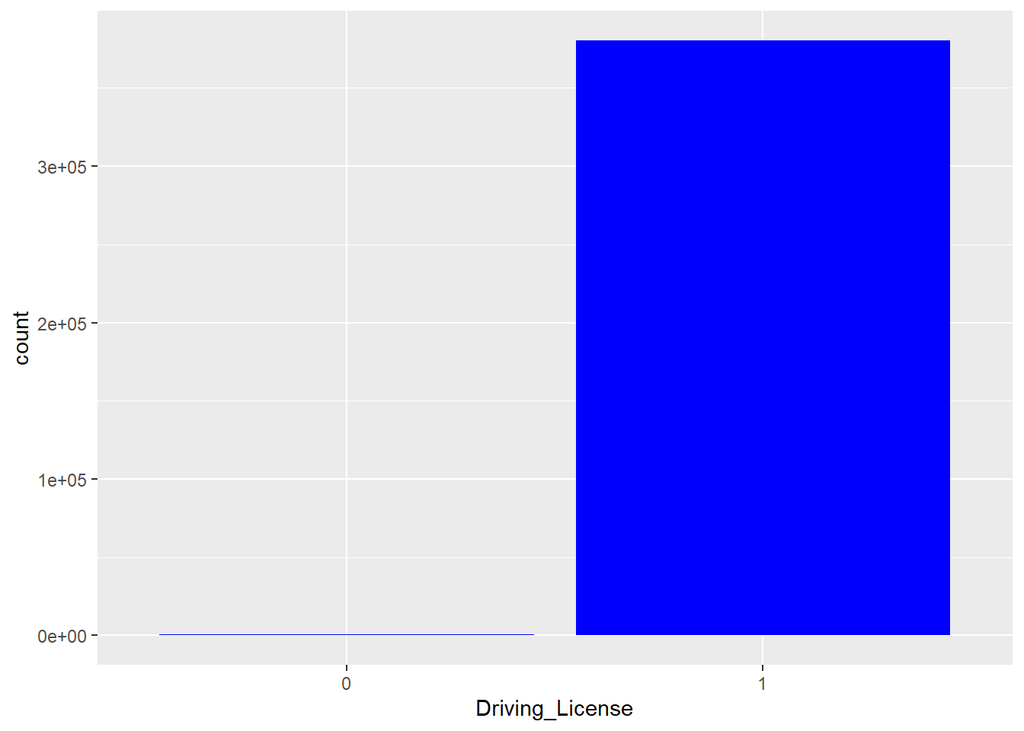

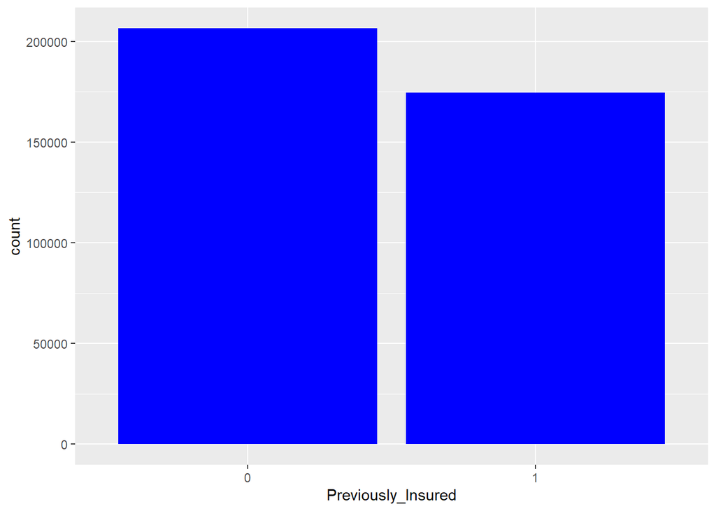

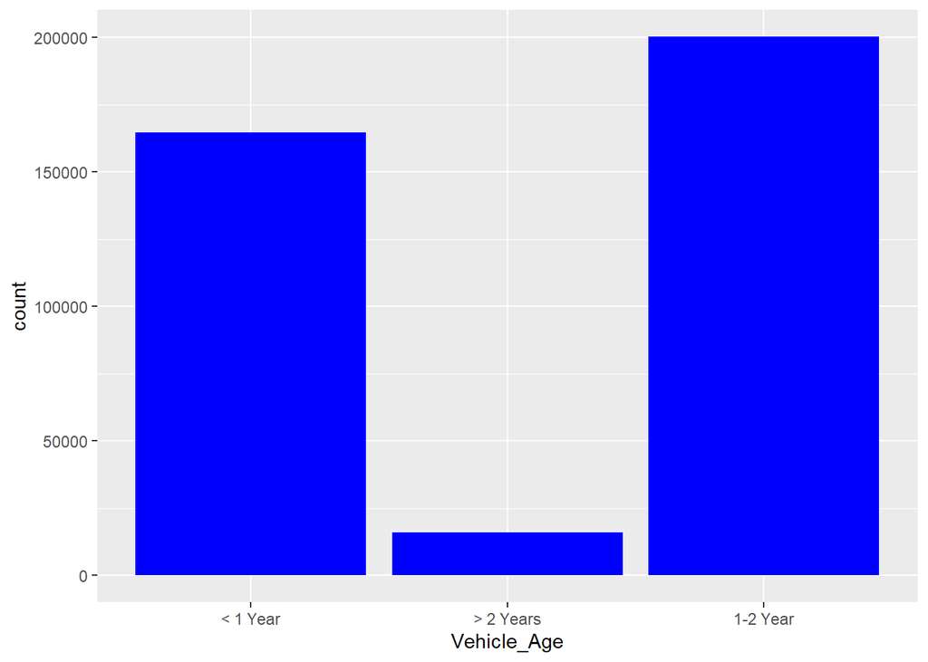

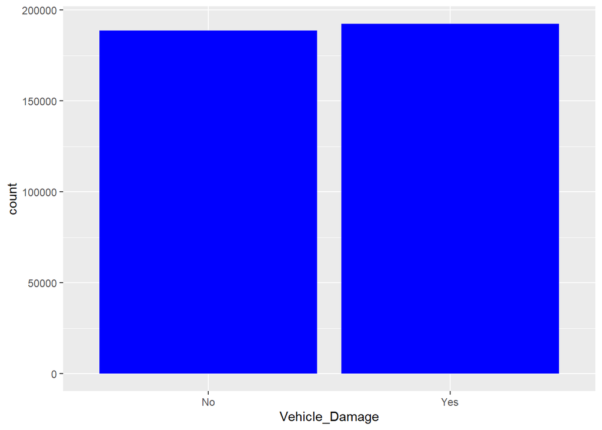

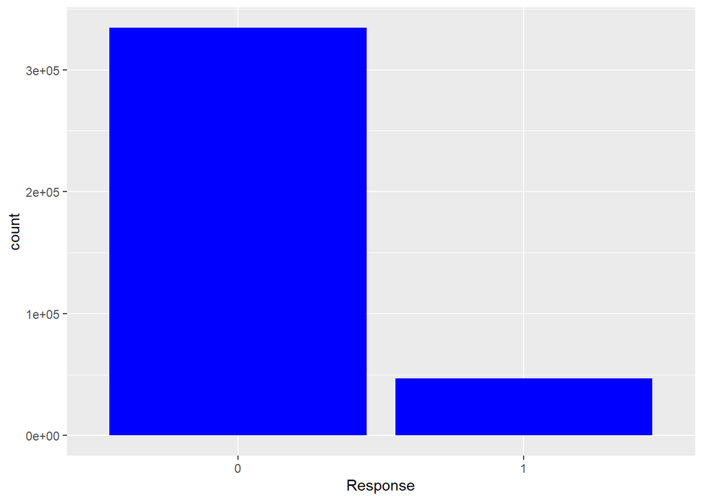

#Driving License does not give us information as it is quite always in 1, #so we shall do not use it

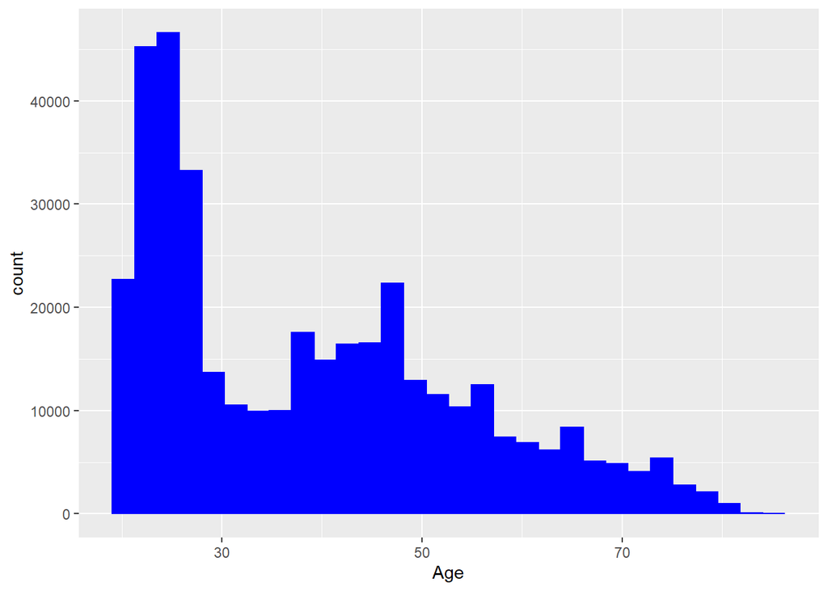

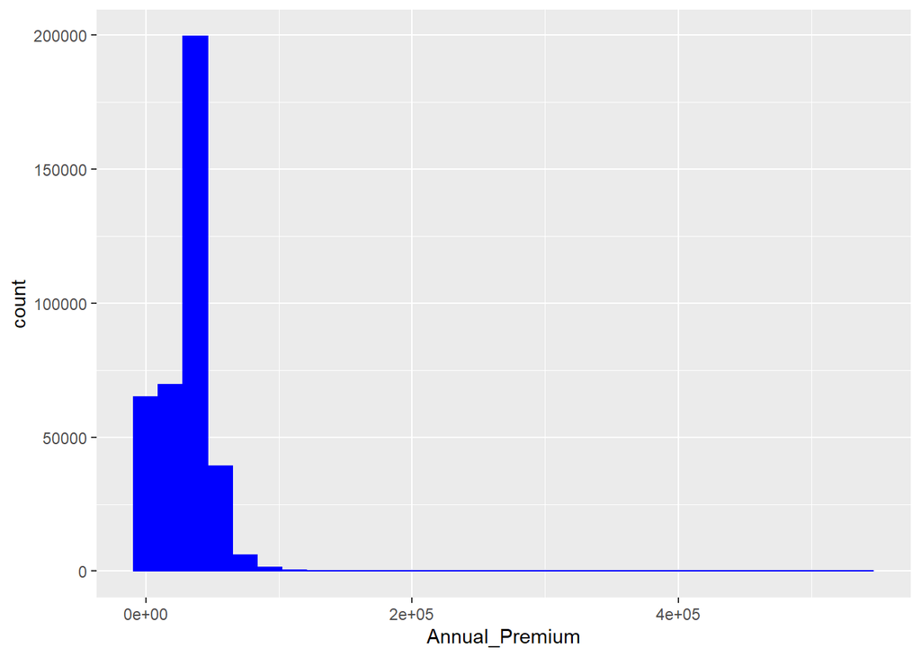

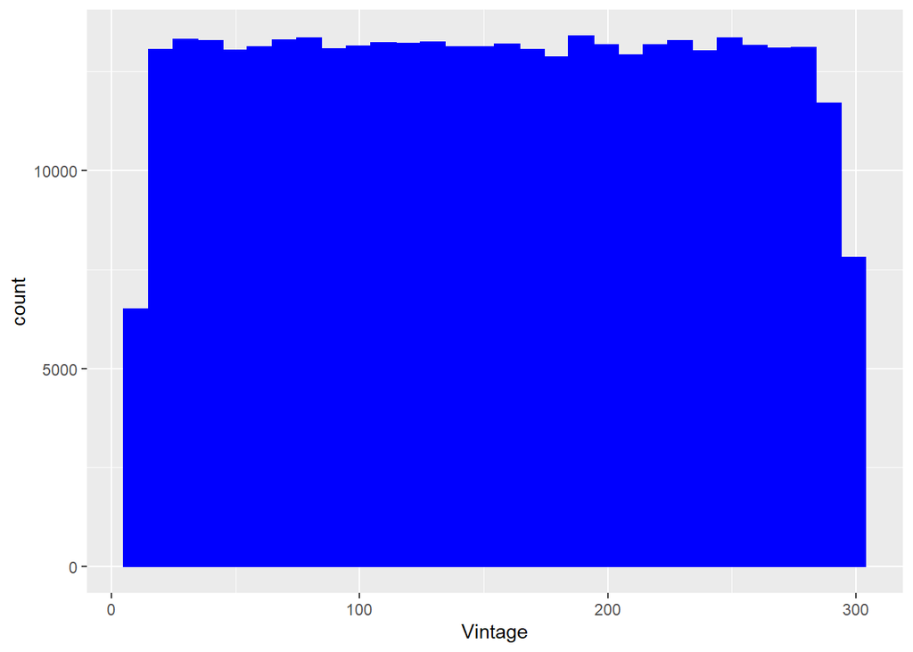

###### BIVARIATE ANALYSIS

#Gender Vs Response

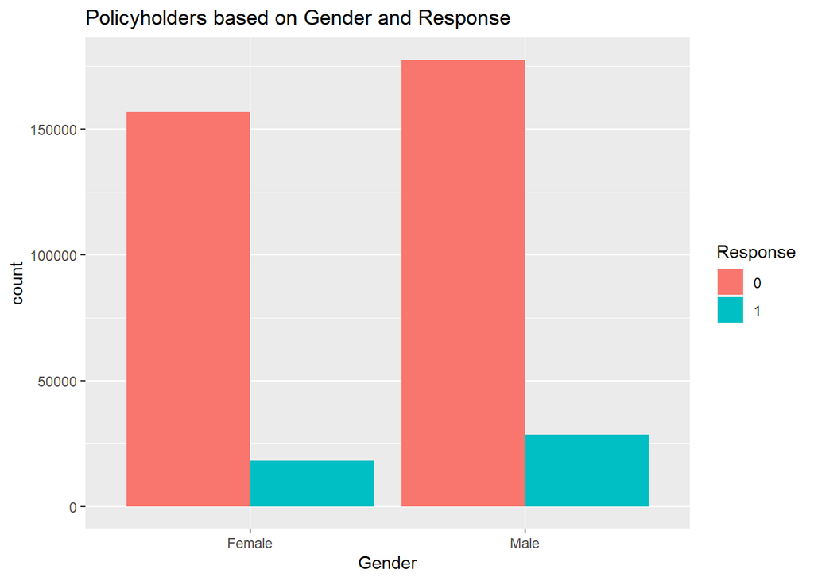

```
##
##               0      1
##   Female 156835  18185
##   Male   177564  28525
```

```
##
##  Pearson's Chi-squared test with Yates' continuity correction
##
## data:  contable
## X-squared = 1047.7, df = 1, p-value < 2.2e-16
```

#RegionCode vs Response

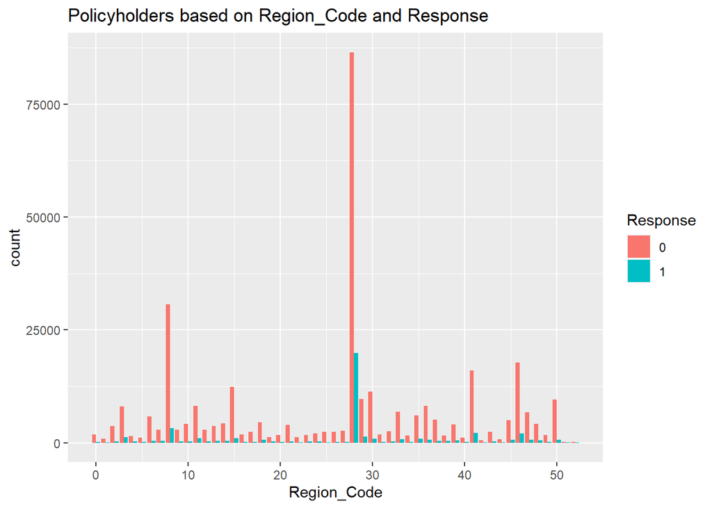

```
##
##          0     1
##   0   1847   174
##   1    899   109
##   2   3751   287
##   3   8070  1181
##   4   1516   285
##   5   1131   148
##   6   5841   439
##   7   2847   432
##   8  30620  3257
##   9   2848   253
##   10  4111   263
##   11  8191  1041
##   12  2886   312
```

[output cut: 40 more lines]

```
##
##  Pearson's Chi-squared test
##
## data:  contable
## X-squared = 7267.8, df = 52, p-value < 2.2e-16
```

#Previously_Insured vs Response

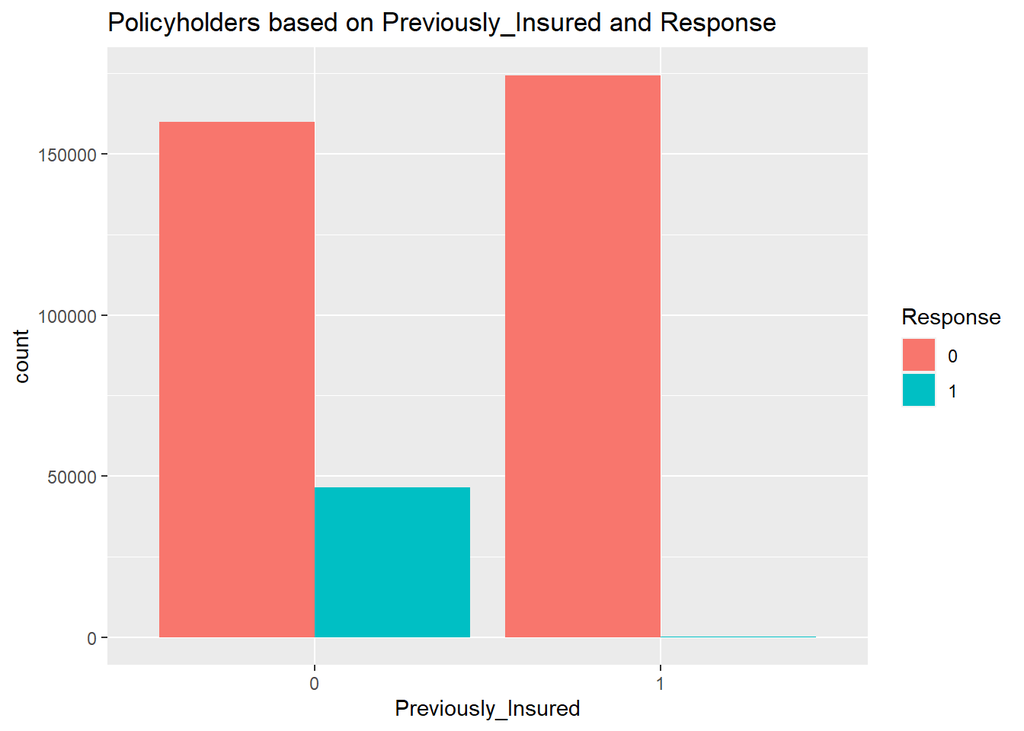

#If it is Previously_Insured almost always reject the offer

```
##
##          0      1
##   0 159929  46552
##   1 174470    158
```

```
##
##  Pearson's Chi-squared test with Yates' continuity correction
##
## data:  contable
## X-squared = 44358, df = 1, p-value < 2.2e-16
```

#It is concluded that the variables Previously_Insured #and Response are not independent (they are asociated) and it could be useful #to include Previously_Insured to predict Response

###### Vehicle_Age vs Response

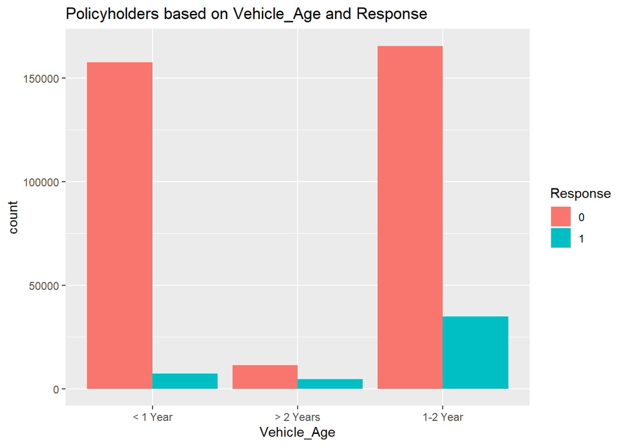

#Vehicles with less than one year of age probably reject the offer

```
##
##                  0      1
##   < 1 Year  157584   7202
##   > 2 Years  11305   4702
##   1-2 Year  165510  34806
```

```
##
##  Pearson's Chi-squared test
##
## data:  contable
## X-squared = 18772, df = 2, p-value < 2.2e-16
```

#It is concluded that the variable ‘Vehicle_Age’ #and Response are not independent (they are asociated) and it could be useful #to include Vehicle_Age to predict Response

######Vehicle_Damage vs Response

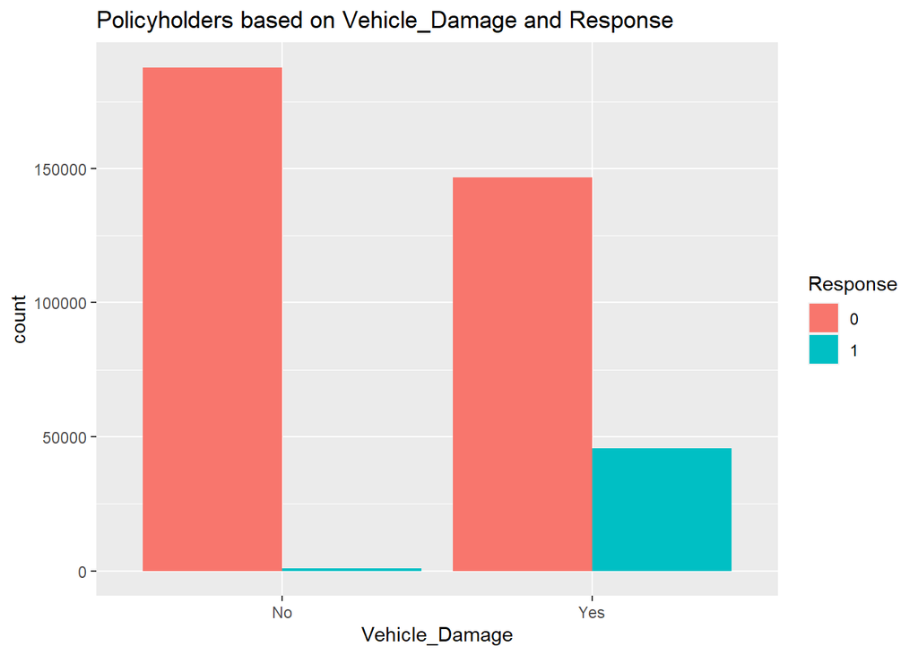

#Vehicles not damaged probably reject the offer

```
##
##            0      1
##   No  187714    982
##   Yes 146685  45728
```

```
##
##  Pearson's Chi-squared test with Yates' continuity correction
##
## data:  contable
## X-squared = 47865, df = 1, p-value < 2.2e-16
```

#Since p-value <0.05 $ H_0 $ is rejected. #It is concluded that the variables Vehicle_Damage #and Response are not independent (they are asociated) and it could be useful #to include Vehicle_Damage to predict Response

#Age vs Response

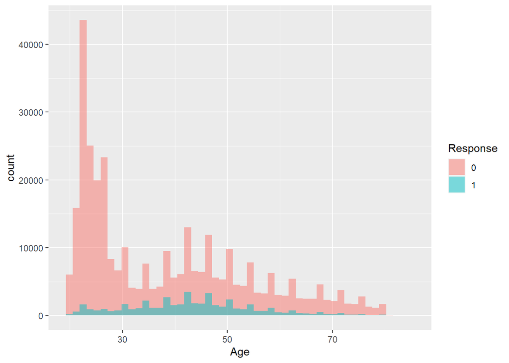

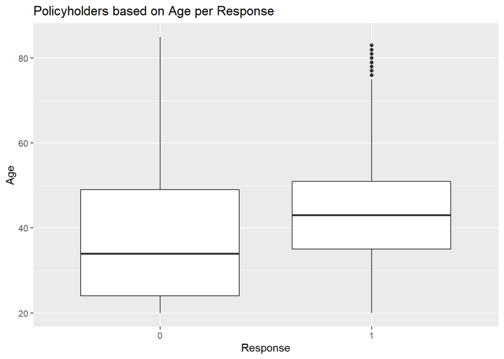

[output not shown]

#Annual_Premium vs Response

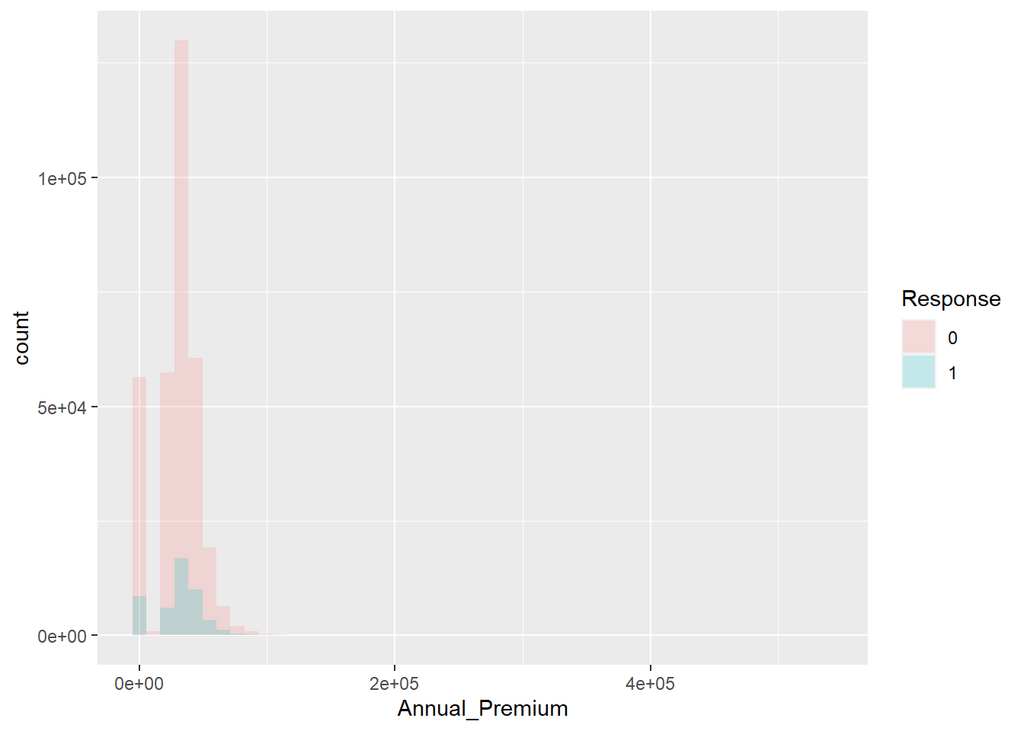

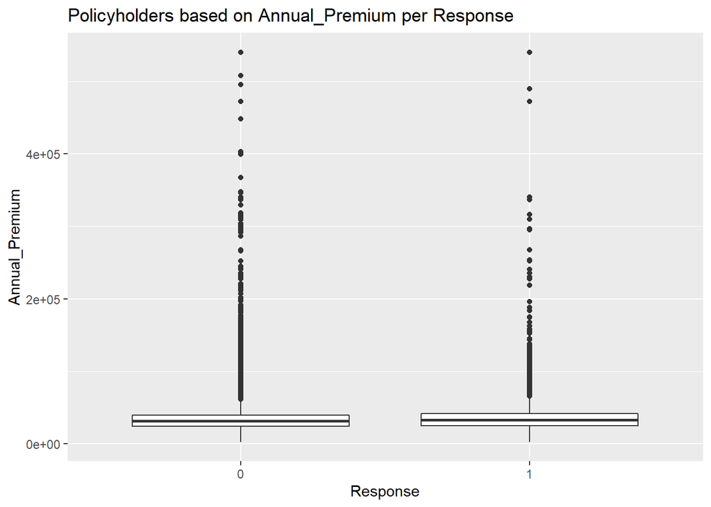

#Variable Annual_Premium has lot of outliers so we will analyze data also removing outliers

[figure not shown]

[figure not shown]